# Getting started in R

[figure not shown]

**R Workshops**

I-Huei (Melanie) Ho Dept. of Statistics, University of Georgia

April 6/April 19, 2018

# Getting Started in R

- Introduction
  - What is R?
  - Advantage
  - Setting Environment
  - Coding Habits
- Modes
  - Numeric Mode
  - Character Mode
  - Logical Mode
  - Changing Modes
  - Factor class
  - Indexing Vectors
  - Generating Sequences
  - Missing Values
- Objects
  - Properties
  - Vectors
  - Arrays
  - List
  - Data Frame
  - Tables
- Data Management
  - Data Export
  - Data Import
  - Manipulate data frame
  - Data Merging
- R Graphics
  - Bar charts
  - Pie charts
  - Histograms
  - Dot Plots
  - Box Plots
  - Scatter Plots
  - Multiple Plots

# Introduction

## What is R?

R is a open-sourced programming language, and a free software environment for data manipulation, calculations, graphical displays that widely used among statisticians and data miners.

R studio is a popular IDE (integrated development environment) of presenting R programming. You can use your console as a calculators, and also run lines of code in the console, but you can run lines in the script pane and save it. All error message appear in the console pane. To use R’s help assistance, just type in `help(pnorm)` or `?pnorm`. (`pnorm` here is a command for obtaining the probability of a specific quantile that normally distributed.)

## Advantage

- Most comprehensive statistical analysis package available
- Graphical capabilities are outstanding
- **Free, open source, no license restrictions**
- over 4800 packages from multiple repositories specializing in topics like econometrics, data mining, spatial analysis, and bio-informatics
- R **plays well with many other tools** for importing data (e.g. SAS, SPSS, STATA, SQL, … etc)

## Packages

R gives some basic and popular functions, but if you need something else, you need to install the package (or library). Some common library: `CRAN` (Comprehansive), `R`, `Archive`, `Network`.

To install a new package, you can:

- **via GUI**:  
  `Tools` tab $\rightarrow$ `Install Packages` tab
- **via command**:  
  `install.packages()`  
  e.g.: to install `MASS` package, use the command `install.packages("MASS")`

You only need to install a package once. To use the package, you must first execute `library()`. Some packages come with datasets, you can load those datasets by `data()`.

For example, if you want to install a new package `MASS` and use the dataset `iris` in that package:

```r
install.packages("MASS")
library(MASS)
data(iris)
```

## Setting Environment

To specify the directory that you will read the datasets from, you have to set up your working directy at the begining by `setwd()`. If you are not sure which directory you are in, use `getwd()` to get the path of the directory.

- `setwd("path/to/your/folder/")`: set working directory
- `getwd()`: get working directory

## Coding Habits

- **Comment your code**,  
  use `#` if you want to comment in the scripts and don’t want R to run it.
- Name your objects (datasets, variables, …) sensibly
- Regularly check your lines are working when you are coding
- Always check your data are read correctly
- Always make sure your output makes sense
- Learn to debug!

# Modes

A vectors of mixed mode are cast to the “highest type”:

- lowest: logical, numeric, complex
- highest: character
- `mode()`: gives the mode of the object

## Numeric Mode

### Order matters

- `x = c(2, 3.2, 6, 1.4, 3, 7.8)`
- Type `x` in console then you will get the `x` vector
- A numeric vector is an ordered collection of numbers
- Entries are preceded by `[1]`, value is a vector

### Using `assign()`

- `assign("x", c(2, 3.2, 6, 1.4, 3, 7.8))`

### Concatenating vectors

- `y = c(x, 0, x)`
- `x = c(1, 2, 3)`, `y = c(4, 5, 6)`  
  `v = 2*x + y + 1`
- Vectors in the same expression don’t have to be of the same length. The shorter vectors are recycled until they match the length of the longest.  
  `x1 = c(1, 2)`, `y1 = c(3, 4, 7, 8)`  
  `x1 + y1 = c(4, 6, 8, 10)`
- R will throw a warning only when the length of the largest is not a multiple of the length of the shortest.  
  `x2 = c(1, 3, 4)`, `y1 = c(3, 4, 7, 8)`  
  `x2 + y1 = error`

### Arithmetic

- Expectation: `a*b`=$a^b$
- Standard functions performed element-wise: `log`, `exp`, `sin`, `cos`, `sqrt`
- Standard functions performed over the whole vector: `sum`, `prod`, `mean`, `var`, `sd`

## Character Mode

- sequence encased in `" "` or `' '`
- `paste()`: concatenation for character variables
  - numbers are cast as characters
  - arguments are separated by a space unless you tell it otherwise

#### Example

```r
### Example 1
y = 2
paste("The value of y is ", y)

### Example 2
labs = paste(c("X", "Y"), 1:10, sep = ""); labs
# sep="": nothing between each values
```

```
> [1] "The value of y is  2"
```

```
>  [1] "X1"  "Y2"  "X3"  "Y4"  "X5"  "Y6"  "X7"  "Y8"  "X9"  "Y10"
```

## Logical Mode

- Takes the values `TRUE`, `FALSE`, `NA`
- logical operations
  - `>`, `<`, `>=`, `<=`
  - `==`, strict equality
  - `!=`, not equals
  - `!`, not
  - `&&`, and
  - `or`, ||`
- Logical vector converts into numeric vector, `FALSE=0`, `TRUE=1`  
  `x = c(1, 1, 3, 6, 4, 1, 3, 1)`  
  `sum(x==1)` gives the count of number of 1’s
- Numeric vector converts into logical vector, `0=FALSE`, `1=TRUE`

## Changing Modes

- Functions:
  - `as.logical()`: changes all elements to boolean
  - `as.numeric()`: changes all elements to numeric
  - `as.character()`: changes all elements to character
  - An element that can’y be transformed gets `NA`

#### Example

```r
x = c(TRUE, FALSE)
y = c(0, 1)
z = c('a', '1')

### Example 1: Changes x into numeric
as.numeric(x)
### Example 2: Changes y into character
as.character(y)
### Example 3: Gets NA if it can't be transformed
mode(z)
as.numeric(z)
```

```
> [1] 1 0
```

```
> [1] "0" "1"
```

```
> [1] "character"
```

```
> Warning: NAs introduced by coercion
```

```
> [1] NA  1
```

## Factor class

- `factor(x)` creates levels using the values in `x`  
  `x = c(1, 1, 2, 3, 1, 5, 5, 7, 7, 1, 3, 2, 6, 5)`  
  `factor(x)` gives levels `1`, `2`, `3`, `5`, `6`, `7`

#### Example

```r
x = c('like', 'dislike', 'hate', 'like', "don't know", 'like', 'dislike')
# Example 1: Not order the levels
factor(x)
# Example 2: Order the levels
factor(x, levels = c('hate', 'dislike', "don't know", 'like'), ordered = TRUE)
```

```
> [1] like       dislike    hate       like       don't know like
> [7] dislike
> Levels: dislike don't know hate like
```

```
> [1] like       dislike    hate       like       don't know like
> [7] dislike
> Levels: hate < dislike < don't know < like
```

## Indexing Vectors

Picks subsets of elements of a vector or matrix

### Logical Index

Keeps the elements that are `TRUE` and drops those that are `FALSE`

#### Example

```r
x = c(1:3, NA, 4)
l = c(T, T, T, F, T)
y = x[l]
y # non-missing elements of x
```

```
## [1] 1 2 3 4
```

### Positive Integers

Can only use values in 1 to the length

#### Example

```r
x = 1:15
### Example 1
x[2:7]
### Example 2
x[c(4, 7, 12)]
### Example 3
index = rep(c(1,1,2,2), times = 2); index
z = c("x","y")
z[index]
```

```
## [1] 2 3 4 5 6 7
```

```
## [1]  4  7 12
```

```
## [1] 1 1 2 2 1 1 2 2
```

```
## [1] "x" "x" "y" "y" "x" "x" "y" "y"
```

### Negative Integers

Excludes those elements

#### Example

```r
x = 1:10
### Original vector
x
### Remove 2th and 5th elements
x[c(-2, -5)]
```

```
>  [1]  1  2  3  4  5  6  7  8  9 10
```

```
> [1]  1  3  4  6  7  8  9 10
```

### Character Index

Only when a name atribute identifies the components

```r
fruit = c(5, 10, 11, 34, 2)
names(fruit) = c('orange', 'banana', 'apple', 'peach', 'grape')
### Original vector
fruit
### Extract values with names of apple and orange
fruit[c('apple', 'orange')]
```

```
> orange banana  apple  peach  grape
>      5     10     11     34      2
```

```
>  apple orange
>     11      5
```

### Replacing elements by index

Assign values to the vectors based on the logical vector as index is true.

```r
x = 1:10
### Extract the vector with TRUE logical index
x[c(T, T, T, F, T)]
### Assign new value to values with TRUE logical index
x[c(T, T, T, F, T)] = 0
x
```

```
> [1]  1  2  3  5  6  7  8 10
```

```
>  [1] 0 0 0 4 0 0 0 0 9 0
```

## Generating Sequences

### :, colon

- `1:30` is equivalent to `c(1, 2, ..., 30)`
- `:`, colon has high priority, in `2*1:15`, colon performs first.

#### Example

```r
n = 10
### Colon performs first
1:n-1
### Generate forward
1:(n-1)
### Generate Backward
5:1
```

```
>  [1] 0 1 2 3 4 5 6 7 8 9
```

```
> [1] 1 2 3 4 5 6 7 8 9
```

```
> [1] 5 4 3 2 1
```

### seq(), sequence

A more general way to generate sequence

#### Example

```r
### Example 1
seq(10)
### Example 2
seq(-1, 1, by = 0.2)
### Example 3
seq(length = 6, from = -5, by = 0.2)
```

```
>  [1]  1  2  3  4  5  6  7  8  9 10
```

```
>  [1] -1.0 -0.8 -0.6 -0.4 -0.2  0.0  0.2  0.4  0.6  0.8  1.0
```

```
> [1] -5.0 -4.8 -4.6 -4.4 -4.2 -4.0
```

### rep(), repeat

#### Example

```r
x = 1:5
### Example 1
rep(x, times = 5)
### Example 2
rep(x, each = 5)
```

```
>  [1] 1 2 3 4 5 1 2 3 4 5 1 2 3 4 5 1 2 3 4 5 1 2 3 4 5
```

```
>  [1] 1 1 1 1 1 2 2 2 2 2 3 3 3 3 3 4 4 4 4 4 5 5 5 5 5
```

## Missing Values

- `NA`: not available, missing
- R does not complete operations if `NA` is present
- Most stat functions have an option for ignoring `NA` (`na.rm = TRUE`)
- `is.na()`
  - returns a logical vector that is `TRUE` where the argument has `NA`, `FALSE` otherwise
  - expression `x==NA` doesn’t work because `NA` is not a value, it is a marker
- `NaN, Inf`
  - `NaN`: Not a Number
  - `Inf`: $\infty$, `Inf` is too big, `-Inf` is too small
  - `is.na()` returns `TRUE` for both `NA` and `NaN`
  - `is.nan()` returns `TRUE` only for `NaN`

#### Example

```r
### Incomplete operation if containing NA
x = 1:15; x[c(1, 3, 6)] = NA
mean(x)
### Some functions have argument for ignoring NA
mean(x, na.rm = TRUE)
### Logical vector of index of NAs
is.na(x)
```

```
> [1] NA
```

```
> [1] 9.166667
```

```
>  [1]  TRUE FALSE  TRUE FALSE FALSE  TRUE FALSE FALSE FALSE FALSE FALSE
> [12] FALSE FALSE FALSE FALSE
```

# Objects

## Properties

Gives different results depends on the object.

- `length(object)`
- `attributes(object)`
- `attr(object, name)`: select a specific attribute
- `class(object)`: gives numeric, logical, character, matrix, array, factor of the object

#### Example

```r
age = 18:29
height = c(76.1, 77, 78.1, 78.2, 78.8, 79.7,
          79.9, 81.1, 81.2, 81.8, 82.8, 83.5)
village = data.frame(age = age, height = height)

### Village, a data frame
village
```

```
>    age height
> 1   18   76.1
> 2   19   77.0
> 3   20   78.1
> 4   21   78.2
> 5   22   78.8
> 6   23   79.7
> 7   24   79.9
> 8   25   81.1
> 9   26   81.2
> 10  27   81.8
> 11  28   82.8
> 12  29   83.5
```

```r
### length()
length(village)
```

```
> [1] 2
```

```r
### attributes()
attributes(village)
```

```
> $names
> [1] "age"    "height"
>
> $row.names
>  [1]  1  2  3  4  5  6  7  8  9 10 11 12
>
> $class
> [1] "data.frame"
```

```r
### class()
class(village)
```

```
> [1] "data.frame"
```

```r
### summary()
summary(village)
```

```
>       age            height
>  Min.   :18.00   Min.   :76.10
>  1st Qu.:20.75   1st Qu.:78.17
>  Median :23.50   Median :79.80
>  Mean   :23.50   Mean   :79.85
>  3rd Qu.:26.25   3rd Qu.:81.35
>  Max.   :29.00   Max.   :83.50
```

## Vectors

- A set of elements of the same mode (where the mode has **numeric**, **character**, **logical**, **complex**)
- can be a single value
- can be extended without special consideration

#### Example

```r
a = c(4, 6, 8)
a[5] = 9
a
```

```
> [1]  4  6  8 NA  9
```

## Arrays

- Data structure of all one type: vector, matrix
- A matrix of dimension $(10 \times 1)$ is not a vector of length $10$
- A matrix and a vector are different objects

### Reshaping vecotr

`matrix(vector, nrow = k, ncol = n)` builds a $k$ by $n$ matrix, column-wise, left to right

#### Example

```r
vector = c(1, 2, 3, 4, 5, 6)
matrix(vector, nrow = 2, ncol = 3)
```

```
>      [,1] [,2] [,3]
> [1,]    1    3    5
> [2,]    2    4    6
```

### Stacking vectors

- `cbind()`: vertical combine columns
- `rbind()`: horizontally combine rows

#### Example

```r
x = c(11, 12, 13)
y = c(77, 55, 33)

### Vectically stacking: 2 by 3 matrix
rbind(x, y)
### Horizontally stacking: 3 by 2 matrix
cbind(x, y)
```

```
>   [,1] [,2] [,3]
> x   11   12   13
> y   77   55   33
```

```
>       x  y
> [1,] 11 77
> [2,] 12 55
> [3,] 13 33
```

### Accessing elements

`matrix[i, j]` gives you value from the `i`th row, `j`th column. Leave it blank if you want to access all columns or all rows.

## List

- Similar as an array, but items can be of different kinds
- Flexible, we can make a list of lists
- `names()` shows named items in a list
- If list itmes are not named, access them with double brackets (`[[]]`)
- You can also create a list using objects already in your workspace

#### Example

```r
### Example 1

L = list() # empty list

# a vector item called coefficients
L$coefficients = c(1, 4, 6, 8)
L
```

```
> $coefficients
> [1] 1 4 6 8
```

```r
# assign item 4, then item 2 and 3 are set to NULL
L[[4]] = c(5, 8)
L
```

```
> $coefficients
> [1] 1 4 6 8
>
> [[2]]
> NULL
>
> [[3]]
> NULL
>
> [[4]]
> [1] 5 8
```

```r
# extract 4th item
L[[4]]
```

```
> [1] 5 8
```

```r
# assign name to item 4
names(L)[[4]] = 'dummy'
L
```

```
> $coefficients
> [1] 1 4 6 8
>
> [[2]]
> NULL
>
> [[3]]
> NULL
>
> $dummy
> [1] 5 8
```

## Data Frame

- Special kind of list where each item (variable) must have the same number of elements. Variables may be different types.
- Can operate with both list commands and array commands

#### Example

```r
### Generate the data frame
grp = c(1,2,2,1,1,1,2,2,1,2,2,1)
gpa = c(4.0, 3.5, 2.8, 3.9, 2.2, 3.8, 2.7, 3.8, 4.0, 3.6, 3.4, 2.1)
age = c(21, 22, 19, 32, 25, 22, 20, 23, 21, 24, 22, 30)
sex = c('F', 'M', 'M', 'M', 'F', 'F', 'M', 'M', 'M', 'F', 'M', 'F')
dat = data.frame(Group = grp, GPA = gpa, Age = age, Sex = sex)
dat

### (1) Access observation 1-10 and all associated variables
dat[1:10,]
### (2) Access all observations in group 1
dat[dat$group==1]
```

```
>    Group GPA Age Sex
> 1      1 4.0  21   F
> 2      2 3.5  22   M
> 3      2 2.8  19   M
> 4      1 3.9  32   M
> 5      1 2.2  25   F
> 6      1 3.8  22   F
> 7      2 2.7  20   M
> 8      2 3.8  23   M
> 9      1 4.0  21   M
> 10     2 3.6  24   F
> 11     2 3.4  22   M
> 12     1 2.1  30   F
```

```
>    Group GPA Age Sex
> 1      1 4.0  21   F
> 2      2 3.5  22   M
> 3      2 2.8  19   M
> 4      1 3.9  32   M
> 5      1 2.2  25   F
> 6      1 3.8  22   F
> 7      2 2.7  20   M
> 8      2 3.8  23   M
> 9      1 4.0  21   M
> 10     2 3.6  24   F
```

```
> data frame with 0 columns and 12 rows
```

## Tables

- Frequency tables
- You can create factor variables via `factor()`
- You can create frequency tables via `table()`
- You can create factor variables by numeric vector via `cut()`
- You can create two way tables of frequency also by `table(a,b)`

#### Example

```r
### 30 tax accountants from Australia
state = c('tas', 'sa', 'qld', 'nsw', 'nsw', 'nt', 'wa', 'wa', 'qld', 'vic', 'nsw', 'vic',
          'qld', 'qld', 'sa', 'tas', 'sa', 'nt', 'wa', 'vic', 'qld', 'nsw', 'nsw', 'wa',
          'sa', 'act', 'nsw', 'vic', 'vic', 'act')

### Create a factor variable
statefac = factor(state)
statefac

### Create a frequency table
statefreq = table(statefac)
statefreq

### Create a factor variable from numeric vector
incomes = c(60, 49, 40, 61, 64, 60, 59, 54, 62, 69, 70, 42,
            56, 61, 61, 61, 58, 51, 48, 65, 49, 49, 41, 48,
            52, 46, 59, 46, 58, 43)
cats = cut(incomes, breaks = 35+10*(0:7))
incomefac = factor(cats)
# breaks: 8 intervals start with 35 and differred with 10
incomefac

### Two-way table
table(incomefac, statefac)
```

```
>  [1] tas sa  qld nsw nsw nt  wa  wa  qld vic nsw vic qld qld sa  tas sa
> [18] nt  wa  vic qld nsw nsw wa  sa  act nsw vic vic act
> Levels: act nsw nt qld sa tas vic wa
```

```
> statefac
> act nsw  nt qld  sa tas vic  wa
>   2   6   2   5   4   2   5   4
```

```
>  [1] (55,65] (45,55] (35,45] (55,65] (55,65] (55,65] (55,65] (45,55]
>  [9] (55,65] (65,75] (65,75] (35,45] (55,65] (55,65] (55,65] (55,65]
> [17] (55,65] (45,55] (45,55] (55,65] (45,55] (45,55] (35,45] (45,55]
> [25] (45,55] (45,55] (55,65] (45,55] (55,65] (35,45]
> Levels: (35,45] (45,55] (55,65] (65,75]
```

```
>          statefac
> incomefac act nsw nt qld sa tas vic wa
>   (35,45]   1   1  0   1  0   0   1  0
>   (45,55]   1   1  1   1  2   0   1  3
>   (55,65]   0   3  1   3  2   2   2  1
>   (65,75]   0   1  0   0  0   0   1  0
```

# Data Management

## Data Export

### Output `.txt` file

#### From a data frame

Use `write.table()` to output a `.txt` file from a data frame

#### Example

```r
age = 18:29
height = c(76.1, 77, 78.1, 78.2, 78.8, 79.7, 79.9, 81.1, 81.2, 81.8, 82.8, 83.5)
village = data.frame(Age = age, Height = height)
### write to a file
write.table(village, file = "village.txt", sep = "\t", col.names = NA, quote = F)
# \t: separate columns by a tab
# makes titles/names align with columns, especially with row name/index
# suppress quotes around character values
```

#### From a matrix

Use `write()` to output a `.txt` file from a matrix

#### Example

```r
x = matrix(1, 20, 20)
write(x, file = "matrix.txt", ncolumns = 20)
```

### Save R objects

Use `save()` to save R objects and you can load the object without reading or conversion later.

#### Example

```r
save(village, file = "village.Rdata")
```

## Data Import

Read files from external files. Generally in a data file, we have:

1. 1st row is the names for the variables
2. Other rows contain variable values separated by space, comma, … etc

### `read.table()`

- Reads a data frame from `txt` file by `read.table("file/name.txt", header = TRUE)`
- Reads variables as numeric or factor by using the argument `colClasses`
- Specifys the delimiter by the argument `sep`
- Some other arguments:
  - `col.names`: specify column names, similar in spirit to `names()`
  - `row.names`: specify row names
  - `skip`: number of lines to skip before reading
  - `na.strings`: how missing values are recorded

#### Example

Instead of specifying the whole path of your file, you can set your working directory of where you put your file.

```r
### Example 1: Reads a data frame
scores = read.table("scores_names.txt", header = TRUE)
scores
# Extract the interesting column by $ or [['']]
scores$gender
scores[['gender']]
# One pair of brackets gives you a data frame of the column
scores['gender']
```

```
>    name gender aptitude statistics
> 1 Linda      F       95         85
> 2 Jason      M       85         95
> 3 Susan      F       80         70
> 4  Mike      M       70         65
> 5  Judy      F       60         70
```

```
> [1] F M F M F
> Levels: F M
```

```
> [1] F M F M F
> Levels: F M
```

```
>   gender
> 1      F
> 2      M
> 3      F
> 4      M
> 5      F
```

```r
### Example 2: Reads variables as numeric or factor
scores = read.table("scores_names.txt", header = TRUE,
                    colClasses = c('character', 'character', 'integer', 'integer'))
scores[['gender']]
```

```
> [1] "F" "M" "F" "M" "F"
```

```r
### Example 3: Specifies the delimiter
reading = read.table("reading.txt")
reading
reading = read.table("reading.txt", sep = ",")
reading
names(reading) = c('Name', 'Week1', 'Week2', 'Week3', 'Week4', 'Week5')
reading
```

```
>                 V1
> 1  Grace,3,1,5,2,6
> 2 Martin,1,2,4,1,3
> 3 Scott,9,10,4,8,6
```

```
>       V1 V2 V3 V4 V5 V6
> 1  Grace  3  1  5  2  6
> 2 Martin  1  2  4  1  3
> 3  Scott  9 10  4  8  6
```

```
>     Name Week1 Week2 Week3 Week4 Week5
> 1  Grace     3     1     5     2     6
> 2 Martin     1     2     4     1     3
> 3  Scott     9    10     4     8     6
```

### `read.fwf()`

Same arguments as `read.table()` but also takes `widths` as vector of integers indicating number of columns a variable occupies. Negative variables are used to skip columns.

#### Example

```r
reading2 = read.fwf("readingfwf.txt", widths = c(6, -9, 1, -3, 2, -3, 1, -2, 1, -1, 1))
reading2
```

```
>       V1 V2 V3 V4 V5 V6
> 1 Grace   3  1  5  2  6
> 2 Martin  1  2  4  1  3
> 3 Scott   9 10  4  8  6
```

### `scan()`

- `read.table()` uses `scan()` and processes the results
- `scan()` does the same thing as `c()` but without commas
- Hit ENTER once, we continue the input onto a new line
- Hit ENTER twice, `scan()` stops

#### Example

Enter the values into Console:

```r
cooperation = scan()
49 64 37 52 68 54
61 79 64 29
27 58 52 41 30 40 39
44 34 44
```

### Built-in datasets

- There are around 100 datasets in base R, package `datasets`
- Other comes with other pacakges
- You can use `data()` to load those datasets, and call them by the name
- You will sometimes need to specify the source package of the datasets

#### Example

```r
data(AirPassengers)
install.pacakges('rpart')
data(kyphosis, package = 'rpart')
```

### Saved R dataset

#### Example

```r
load('village.Rdata')
```

## Manipulate data frame

#### Example

```r
data(airquality)
head(airquality)
```

```
>   Ozone Solar.R Wind Temp Month Day
> 1    41     190  7.4   67     5   1
> 2    36     118  8.0   72     5   2
> 3    12     149 12.6   74     5   3
> 4    18     313 11.5   62     5   4
> 5    NA      NA 14.3   56     5   5
> 6    28      NA 14.9   66     5   6
```

```r
nrow(airquality)
```

```
> [1] 153
```

```r
### Example 1: change Month to a factor
airquality$Month = factor(airquality$Month)

### Example 2: create new indicator variable Solar.I=1 if solar.R > 200
airquality$Solar.I = ifelse(airquality$Solar.R > 200, 1, 0)

### Example 3: replace Temp and Ozone with their z-scores
airquality$Temp = (airquality$Temp - mean(airquality$Temp)) / sd(airquality$Temp)
airquality$Ozone = (airquality$Ozone - mean(airquality$Ozone, na.rm = T)) / sd(airquality$Ozone, na.rm = T)

### Example 4: add a new variable
airquality$New = 1:153

### Example 5: Remove variable Day (column 6)
airquality = airquality[,-6]

### Example 6: Remove all observations with NA for Ozone and Solar.R
airquality = airquality[!is.na(airquality$Solar.R) & !is.na(airquality$Ozon),]

### Print out the manipulated dataset
head(airquality)
```

```
>         Ozone Solar.R Wind       Temp Month Solar.I New
> 1 -0.03423409     190  7.4 -1.1497140     5       0   1
> 2 -0.18580489     118  8.0 -0.6214670     5       0   2
> 3 -0.91334473     149 12.6 -0.4101682     5       0   3
> 4 -0.73145977     313 11.5 -1.6779609     5       1   4
> 7 -0.57988897     299  8.6 -1.3610128     5       1   7
> 8 -0.70114561      99 13.8 -1.9949091     5       0   8
```

```r
nrow(airquality)
```

```
> [1] 111
```

## Data Merging

### Vertical Merging

- vertical binding of data frames
- does not fill in NAs for variables that are missing in one data frame

#### Example

```r
X = data.frame(a = c(1, 2, 3, 4), b = factor(c(1, 2, 2, 1)), c = c('A', 'B', 'B', 'A'))
Y = data.frame(a = c(3, 7, 8), b = factor(c(3, 3, 3)))
# rbind(X, Y) gives Error: variables number are different
# Fill NA values yourself
Y$c = 'NA'
rbind(X, Y)
```

```
>   a b  c
> 1 1 1  A
> 2 2 2  B
> 3 3 2  B
> 4 4 1  A
> 5 3 3 NA
> 6 7 3 NA
> 7 8 3 NA
```

### Horizontal Merging

- `merge()` by arguments
- If there are identical variable names in the data frames, `merge()` will modify the name to indicate which data frame the variable comes from

#### Example

```r
A = data.frame(ID = c(1, 2, 3), age = c(11, 12, 14))
B = data.frame(ID = c(2, 3, 4), sex = c('M', 'M', 'F'))

### Merge two data frame by ID
# keep only the ID values in common to A and B
merge(A, B, by = c('ID'))
### Merge two data frame by ID and keep only t
# keep all ID values even there are missing values
merge(A, B, all = TRUE)
```

```
>   ID age sex
> 1  2  12   M
> 2  3  14   M
```

```
>   ID age  sex
> 1  1  11 <NA>
> 2  2  12    M
> 3  3  14    M
> 4  4  NA    F
```

### One-to-Many merge

#### Example

```r
C = data.frame(ID = c(1, 1, 2, 1, 3, 3, 3, 4, 4), stars = c(1, 4, 3, 2, 1, 7, 5, 2, 2))
### Order by merge(A,B)
merge(merge(A, B, by = c('ID'), all = TRUE), C, by = c('ID'), all = TRUE)
### Order by C
merge(C, merge(A, B, by = c('ID'), all = TRUE), by = c('ID'), all = TRUE)
```

```
>   ID age  sex stars
> 1  1  11 <NA>     1
> 2  1  11 <NA>     4
> 3  1  11 <NA>     2
> 4  2  12    M     3
> 5  3  14    M     1
> 6  3  14    M     7
> 7  3  14    M     5
> 8  4  NA    F     2
> 9  4  NA    F     2
```

```
>   ID stars age  sex
> 1  1     1  11 <NA>
> 2  1     4  11 <NA>
> 3  1     2  11 <NA>
> 4  2     3  12    M
> 5  3     1  14    M
> 6  3     7  14    M
> 7  3     5  14    M
> 8  4     2  NA    F
> 9  4     2  NA    F
```

# R Graphics

General functions for all graphics: `title()`, `legend()`, `axis()`, etc.

## Bar Charts

25 people were asked for the beer preference. 1 for domestic can, 2 for domestic bottle, 3 for microbrew, and 4 for import.

### Bar plot

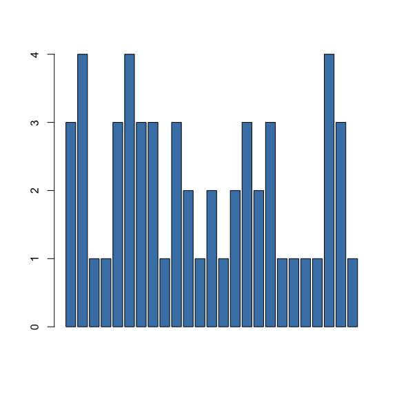

```r
beer = c(3, 4, 1, 1, 3, 4, 3, 3, 1, 3, 2, 1, 2, 1, 2, 3, 2, 3, 1, 1,
         1, 1, 4, 3, 1)
barplot(beer, col = "SteelBlue")
```

### Bar plot by frequency

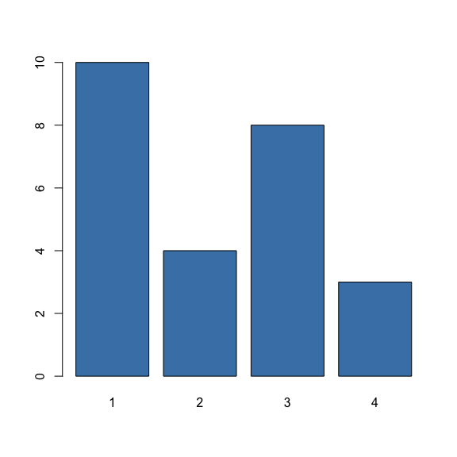

```r
barplot(table(beer), col = "SteelBlue")
```

### Bar plot by propotion

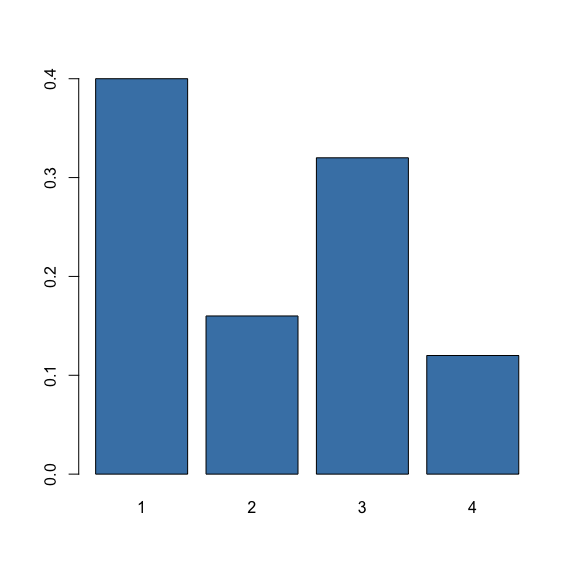

```r
barplot(table(beer)/length(beer), col = "SteelBlue")
```

### Bar plot by propotion horizontally

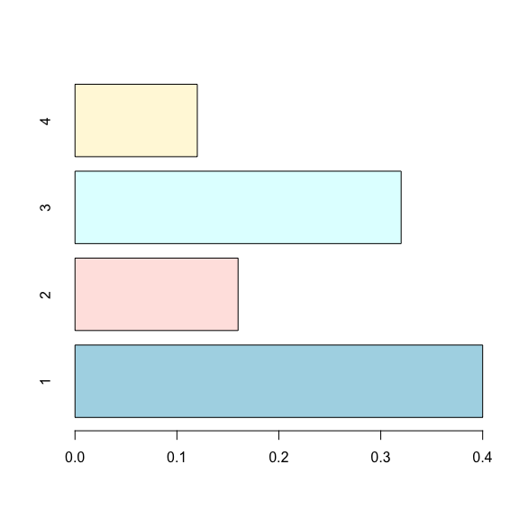

```r
barplot(table(beer)/length(beer), col = c('lightblue', 'mistyrose', 'lightcyan', 'cornsilk'),
        horiz = T)
```

## Pie Charts

### Pie chart

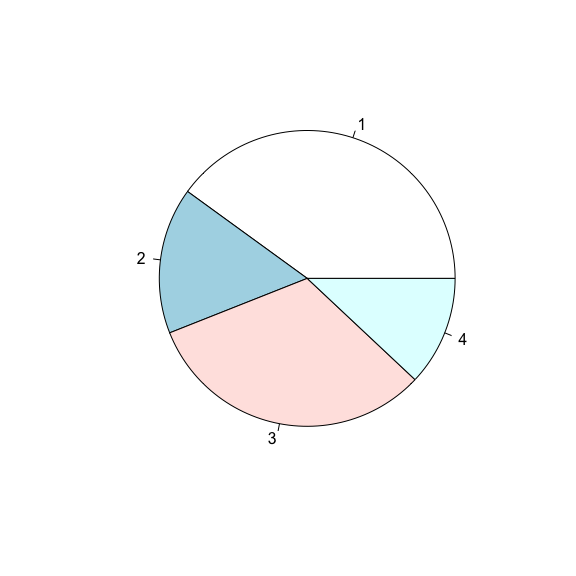

```r
beer.counts = table(beer)
pie(beer.counts)
```

### Pie chart with variable labels

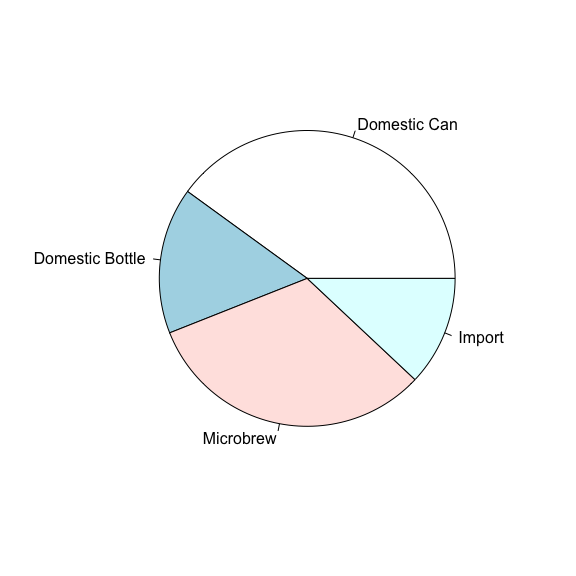

```r
names(beer.counts) = c('Domestic Can', 'Domestic Bottle', 'Microbrew', 'Import')
pie(beer.counts)
```

### Pie chart with colors

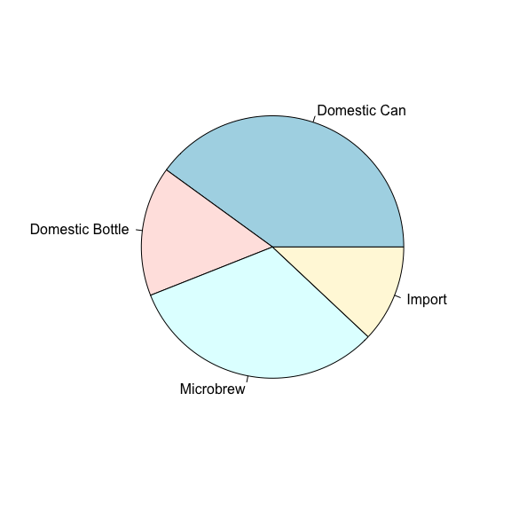

```r
pie(beer.counts, col = c('lightblue', 'mistyrose', 'lightcyan', 'cornsilk'))
```

## Histograms

Top 25 movies on 4th-week gross receipts.

### Histogram by frequency

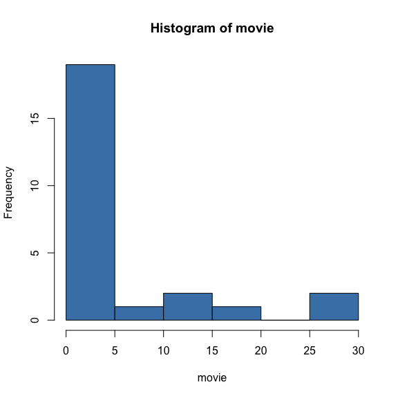

```r
movie = c(29.6, 28.2, 19.6, 13.7, 13.0, 7.8, 3.4, 2.0, 1.9, 1.0,
          0.7, 0.4, 0.4, 0.3, 0.3, 0.3, 0.3, 0.3, 0.2, 0.2,
          0.2, 0.1, 0.1, 0.1, 0.1)
hist(movie, col = "SteelBlue")
```

### Histogram by proportion

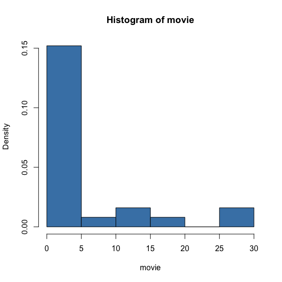

```r
hist(movie, freq = F, col = "SteelBlue")
```

### Historgrm by specified bins

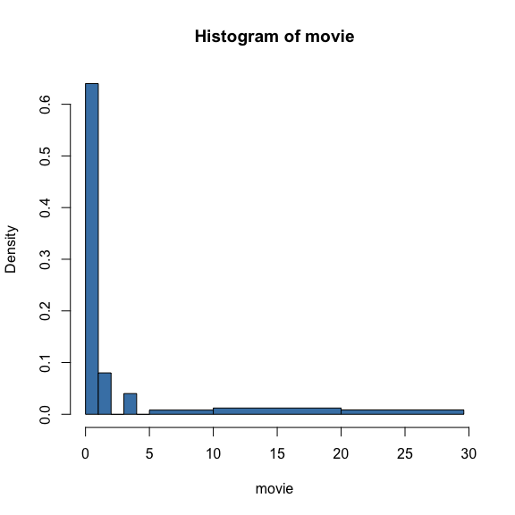

```r
hist(movie, col = "SteelBlue", breaks = c(0, 1, 2, 3, 4, 5, 10, 20, max(movie)))
```

## Dot Plots

Use the built-in dataset `mtcars`.

### Dot plot

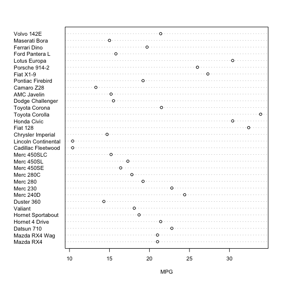

```r
dotchart(mtcars$mpg, labels = row.names(mtcars), cex = 0.7, xlab = 'MPG')
```

### Dot plot colored by `cyl` and ordered by `mpg`

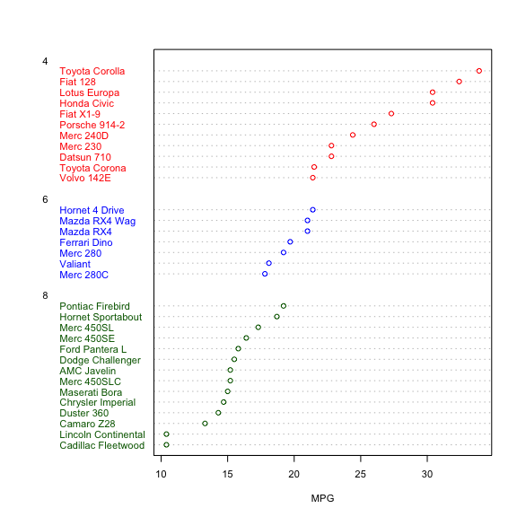

```r
x = mtcars[order(mtcars$mpg), 1:2] #mpg:cyl
x$cyl = factor(x$cyl)
x$color[x$cyl==4]='red'
x$color[x$cyl==6]='blue'
x$color[x$cyl==8]='darkgreen'
dotchart(x$mpg, labels = row.names(x), cex = 0.7,
         groups = x$cyl, color = x$color, xlab = 'MPG')
```

## Box Plots

Based on 5-number summary: `min`, `1stQ`, `med`, `3rdQ`, `max`

### Single sample

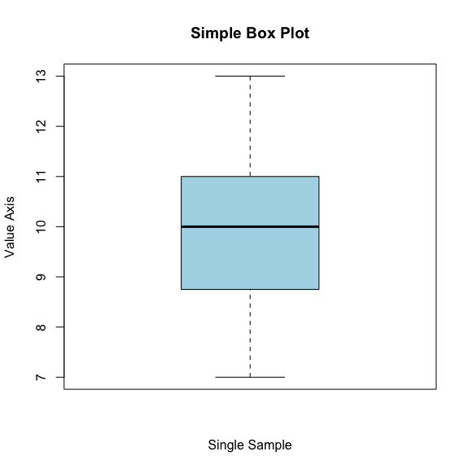

```r
x = c(7, 9.5, 10, 11, 10, 10, 8, 11, 8, 13, 11.5)
boxplot(x, xlab = 'Single Sample', ylab = 'Value Axis', main = 'Simple Box Plot', col = 'lightblue')
```

### Multiple Samples

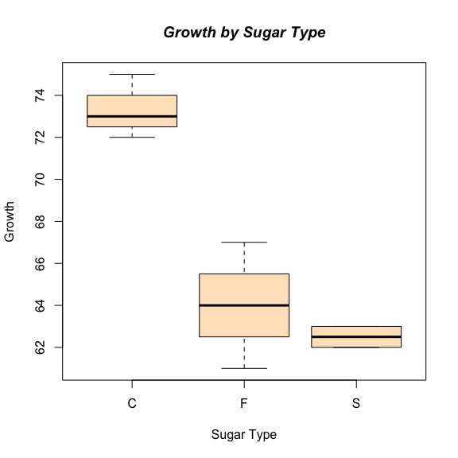

```r
growth = c(75, 72, 73, 61, 67, 64, 62, 63)
sugar = c('C', 'C', 'C', 'F', 'F', 'F', 'S', 'S')
fly = data.frame(growth = growth, sugar = sugar)

boxplot(growth~sugar, data = fly, xlab = 'Sugar Type', ylab = 'Growth', col = 'bisque')
title(main = 'Growth by Sugar Type', font.main = 4)
```

## Scatter Plots

Use the notation `plot(x, y, ...)` or `plot(y ~ x, ...)`

### Scatter plot

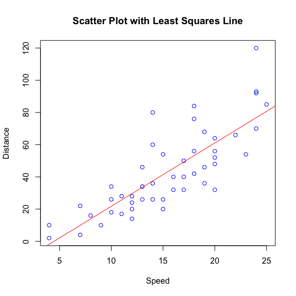

```r
plot(dist~speed, data = cars, xlab = 'Speed', ylab = 'Distance', col = 'blue')
title(main = 'Scatter Plot with Least Squares Line')
abline(lm(dist~speed, data = cars), col = 'red')
```

### Scatter plot matrix

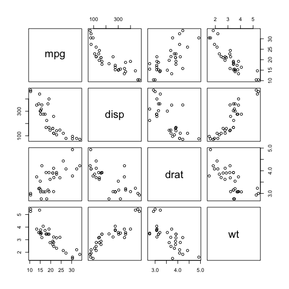

```r
pairs(~mpg+disp+drat+wt, data = mtcars)
```

## Multiple Plots

### number of plots in the graph window

- `par()`
- `layout()`

#### Example

```r
### Example 1
# a window of two graphs
par(mfrow = c(2, 1))

### Example 2
# a window of four graphs
layout(matrix(c(1, 3, 2, 4), 2, 2, byrow = T),
       widths = c(3, 1), heights = c(1, 2))
```

### clear and return to defaults

```r
dev.off()
```